# Property Price Prediction

Bhargav Pandya

08 January, 2024

```r
# install.packages("installr")
#
# library(installr)
#
# updateR()


# install.packages('devtools')     # comment this line if already installed
library(skimr)                  # load library
library(tidyverse)              # load library
library(validate)
library(stringr)
```

# 1. Organise and clean the data

## 1.1 Subset the data into the specific dataset allocated

```r
# Assign your student id into the variable SID, for example:
SID <- 2203089                  # replaced with my student ID 2203089
SIDoffset <- (SID %% 100) + 1    # Your SID mod 100 + 1

load("house-analysis.RDa")
# Now subset the housing data set
# Pick every 100th observation starting from your offset
# Put into your data frame named mydf (you can rename it)
originalDF <- house.analysis[seq(from=SIDoffset,to=nrow(house.analysis),by=100),]
```

## 1.2 Data quality analysis

At First, I will make user define function to for every “quality check”, and then I will call those quality check functions. Main purpose of following this method is that I can re-use same code in future projects.

To access the quality of data I would follow following plan and steps.

1. Initially, I will take back up Original data frame (originalDF) and process on new dataframe (newdf) before continuing. The main purpose of doing this is, Our original data will remain untouched as a backup in the “originalDF” data frame. It is regarded as a good practise.
2. Then, I will just take overview of data before data cleaning using skim() function from skimr library. I know, skim() does not work well with NA and NAN values, before data cleaning, but it is a good practice to take overview of data before start working.
3. **Integrity check** Then, I will make user define function for “Integrity check”, to make sure all columns in dataframe follows integrity critaria. I will use validator function from validate library for that. I will make sure that data must follow following rule book.

Rule book:-

1. ‘heating’ column must have only 2 types of values ‘autonomous’ and ‘other’
2. Price must be grater than 0 (zero).
3. mq column (area) must be grater than 0 (zero).
4. floors must be grater than 0 (zero).
5. number of rooms (n_rooms) must be grater than 0 (zero).
6. number of bathrooms (n_bathrooms) must have non negative value.
7. ‘has_terrace’ column must have either “0” or “1” value.
8. ‘has_alarm’ column must have either “0” or “1” value.
9. ‘has_air_conditioning’ column must have either “0” or “1” value.
10. ‘has_parking’ column must have either “0” or “1” value.
11. ‘is_furnished’ column must have either “0” or “1” value.
12. *Missing value check* To perform an accurate and objective analysis, I must remove all NA and NAN values from the data frame. I will therefore add a missing value check for each column.

If a NA or NAN values exists in a dataset, it can be handled in a variety of ways, including deleting the rows (observations) or imputation technique applying the mean (avarage value), median (mid point value), or mode (most common value) value to that observation.

Situation to apply Mean, median and mode :-

1. Mean :- It is preferred if data is numeric and not skewed. But drawback is, outliers has severe impacts on mean value. We have to consider outliers factor before applying mean value as a replacement of NA and NAN value.
2. Median :- It is preferred if data is numeric and skewed.
3. Mode :- It is preferred if the data is a string(object) or numeric.

In this data frame, 903 rows are available. Therefore, if few NA values exists, I will choose ‘remove’ option for that. If the dataset contains many missing values, I would replace with the mean value of that column.

5. **Uniqueness check**

I will make function for checking duplicate rows in dataframe..

6. **Variable type check** I will check class of all columns name in our dataframe. This step is important for data analysis.
7. **Accuracy Check** There are several different methods for identifying and removing outliers in a data set, like removing values which is above 3 standard deviations from mean value or Boxplot can be used to identify outliers or we can put cap values on certain threshold. For that, I have chosen 5000 for lower cap and 1000000 for upper cap for price column.

In real life scenario, I would discuss this with client or domain expert before taking decision. In our case, I will remove outliers of price column.

8. **Special character Check**

I will Check that any special character exist or not in any columns using this check, for that I will use stringr library for that.

9. **Quality Check for area (mq)** According to me, property area which has less than 25 value (mq) should not exist. So, I will remove those rows which has less than 25 value in mq column.
10. Then, I will start implement all checks by calling all user define function one by on. I will also convert blank values “” in to NA before implementing missing value check.

**Taking back up the data**

```r
newdf <- originalDF # taking back up of data frame
dim(newdf) # returns the dimension (number of rows and columns) of data frame
```

```
[1] 903  12
```

```r
head(newdf, 5)     # visualize top 5 rows
```

|  | id | price | mq | floor | n_rooms | n_bathrooms | has_terrace | has_alarm | heating | has_air_conditioning | has_parking | is_furnished |
| --- | --- | --- | --- | --- | --- | --- | --- | --- | --- | --- | --- | --- |
| 153 | 153 | 85000 | 92 | 1 | 4 | 1 | 0 | 0 | autonomous | 0 | 0 | 0 |
| 363 | 363 | 99000 | 110 | 2 | 5 | 1 | 0 | 0 | autonomous | 1 | 0 | 0 |
| 583 | 583 | 49000 | 53 | 1 | 3 | 1 | 0 | 0 | autonomous | 1 | 0 | 1 |
| 795 | 795 | 65000 | 95 | 3 | 3 | 2 | 0 | 0 | autonomous | 1 | 0 | 0 |
| 1070 | 1070 | 68000 | 98 | 1 | 3 | 1 | 0 | 0 | autonomous | 0 | 0 | 0 |

**Skimming the data and getting summary**

```r
skim(newdf)
```

```
── Data Summary ────────────────────────
                           Values
Name                       newdf
Number of rows             903
Number of columns          12
_______________________
Column type frequency:
  character                1
  numeric                  11
________________________
Group variables            None
```

|  | skim_variable | n_missing | complete_rate | min | max | empty | n_unique | whitespace |
| --- | --- | --- | --- | --- | --- | --- | --- | --- |
| 1 | heating | 0 | 1 | 5 | 10 | 0 | 3 | 0 |

|  | skim_variable | n_missing | complete_rate | mean | sd | p0 | p25 | p50 | p75 | p100 | hist |
| --- | --- | --- | --- | --- | --- | --- | --- | --- | --- | --- | --- |
| 1 | id | 0 | 1 | 1.111006e+05 | 6.485560e+04 | 153 | 54002 | 113219 | 167293 | 223176 | ▇▇▇▇▇ |
| 2 | price | 0 | 1 | 1.462505e+05 | 1.020249e+05 | 7000 | 75000 | 120000 | 190000 | 500000 | ▇▆▂▁▁ |
| 3 | mq | 0 | 1 | 1.159590e+02 | 8.152836e+01 | 0 | 75 | 98 | 130 | 925 | ▇▁▁▁▁ |
| 4 | floor | 0 | 1 | 1.805094e+00 | 1.123078e+00 | 1 | 1 | 1 | 2 | 9 | ▇▂▁▁▁ |
| 5 | n_rooms | 0 | 1 | 3.439646e+00 | 9.902298e-01 | -1 | 3 | 3 | 4 | 5 | ▁▁▃▆▇ |
| 6 | n_bathrooms | 0 | 1 | 1.434109e+00 | 5.935999e-01 | 1 | 1 | 1 | 2 | 3 | ▇▁▅▁▁ |
| 7 | has_terrace | 0 | 1 | 1.339978e-01 | 3.408387e-01 | 0 | 0 | 0 | 0 | 1 | ▇▁▁▁▁ |
| 8 | has_alarm | 0 | 1 | 1.328904e-02 | 1.145730e-01 | 0 | 0 | 0 | 0 | 1 | ▇▁▁▁▁ |
| 9 | has_air_conditioning | 0 | 1 | 3.156146e-01 | 4.650177e-01 | 0 | 0 | 0 | 1 | 1 | ▇▁▁▁▃ |
| 10 | has_parking | 0 | 1 | 1.439646e-02 | 1.191844e-01 | 0 | 0 | 0 | 0 | 1 | ▇▁▁▁▁ |

[output cut: 1 more lines]

**Display all column names in data frame.**

```r
colnames(newdf)
```

```
 [1] "id"                   "price"                "mq"                   "floor"                "n_rooms"
 [6] "n_bathrooms"          "has_terrace"          "has_alarm"            "heating"              "has_air_conditioning"
[11] "has_parking"          "is_furnished"
```

**Integrity check**

```r
integrity.rules <- validator(okHeating = is.element(heating,c("autonomous","other")),
                             NonNegPrice = price > 0,
                             NonNegMq = mq > 0,
                             NonNegFloor = floor > 0,
                             NonNegNrooms = n_rooms > 0,
                             NonNegNbathrooms = n_bathrooms >= 0,
                             OKNegTerrace = is.element(has_terrace,c("0","1")),
                             OkNegAlarm = is.element(has_alarm,c("0","1")),
                             OkNegAirconditioning = is.element(has_air_conditioning,c("0","1")),
                             OkNegParking = is.element(has_parking,c("0","1")),
                             OkNegfurnished = is.element(is_furnished,c("0","1"))
                         )
```

*Missing value check*

```r
missing.rules <- validator(
                           missing.NA_price = !is.na(price),
                           missing.NAN_price = !is.nan(price),

                           missing.NA_mq = !is.na(mq),
                           missing.NAN_mq = !is.nan(mq),

                           missing.NA_floor = !is.na(floor),
                           missing.NAN_floor = !is.nan(floor),

                           missing.NA_n_rooms = !is.na(n_rooms),
                           missing.NAN_n_rooms = !is.nan(n_rooms),

                           missing.NA_n_bathrooms = !is.na(n_bathrooms),
                           missing.NAN_n_bathrooms = !is.nan(n_bathrooms),

                           missing.NA_has_terrace = !is.na(has_terrace),
                           missing.NAN_has_terrace = !is.nan(has_terrace),

                           missing.NA_has_alarm = !is.na(has_alarm),
                           missing.NAN_has_alarm = !is.nan(has_alarm),

                           missing.NA_heating = !is.na(heating),
                           missing.NAN_heating = !is.nan(heating),

                           missing.NA_has_air_conditioning = !is.na(has_air_conditioning),
                           missing.NAN_has_air_conditioning = !is.nan(has_air_conditioning),

                           missing.NA_has_parking = !is.na(has_parking),
                           missing.NAN_has_parking = !is.nan(has_parking),

                           missing.NA_is_furnished = !is.na(is_furnished),
                           missing.NAN_is_furnished = !is.nan(is_furnished)
)
```

**Uniqueness check**

```r
unique_check <- function(data) {
  duplicates <- duplicated(data)
  unique_data <- data[!duplicates, ]
  return(unique_data)
}
```

**Variable type check**

```r
variabletype.rule <- validator(
    variable_price = is.numeric(price),
    variable_mq = is.numeric(mq),

    variable_floor = is.factor(floor),
    variable_n_rooms = is.factor(n_rooms),
    variable_n_bathrooms = is.factor(n_bathrooms),
    variable_has_terrace = is.factor(has_terrace),
    variable_has_alarm = is.factor(has_alarm),
    variable_heating = is.factor(heating),
    variable_has_air_conditioning = is.factor(has_air_conditioning),
    variable_has_parking = is.factor(has_parking),
    variable_is_furnished = is.factor(is_furnished)
)
```

**Accuracy Check**

```r
remove_outliers_cap <- function(data, upper_threshold, lower_threshold) {
  # Identify the outliers as data points above the upper threshold or below the lower threshold
  outliers <- newdf[newdf$price > upper_threshold | newdf$price < lower_threshold, ]


  # Cap the values at the thresholds
  newdf$price[newdf$price > upper_threshold] <- upper_threshold
  newdf$price[newdf$price < lower_threshold] <- lower_threshold


  # Remove the outliers from the data set
  filtered_data <- newdf[newdf$price >= lower_threshold & newdf$price <= upper_threshold, ]


  return(filtered_data)  # Return the data set without the outliers
}
```

**Checking any special character exist or not in columns**

```r
check_special_characters <- function(data, columns) {

  # Initialize a list to store the results
  results <- list()

  # Loop through each column
  for (col in columns) {
    # Check if any values in the column contain a special character
    special_characters_mask <- str_detect(data[, col], "[^[:alnum:]]")

    # Check if any values were identified as containing a special character
    if (any(special_characters_mask)) {
      results[[col]] <- "Special characters found in column."
    } else {
      results[[col]] <- "No special characters found in column."
    }
  }

  # Return the results
  return(results)
}
```

**Implementing data cleaning**

**Now, converting blank data “” into NA in each column.**

```r
newdf["id"][newdf["id"] == ''] <- NA
newdf["price"][newdf["price"] == ''] <- NA
newdf["mq"][newdf["mq"] == ''] <- NA
newdf["floor"][newdf["floor"] == ''] <- NA
newdf["n_rooms"][newdf["n_rooms"] == ''] <- NA
newdf["n_bathrooms"][newdf["n_bathrooms"] == ''] <- NA
newdf["has_terrace"][newdf["has_terrace"] == ''] <- NA
newdf["has_alarm"][newdf["has_alarm"] == ''] <- NA
newdf["heating"][newdf["heating"] == ''] <- NA
newdf["has_air_conditioning"][newdf["has_air_conditioning"] == ''] <- NA
newdf["has_parking"][newdf["has_parking"] == ''] <- NA
newdf["is_furnished"][newdf["is_furnished"] == ''] <- NA
```

**Integrity check**

```r
qualcheck_integrity <-confront(newdf,integrity.rules)
summary(qualcheck_integrity)
```

| name | items | passes | fails | nNA | error | warning | expression |
| --- | --- | --- | --- | --- | --- | --- | --- |
| okHeating | 903 | 902 | 1 | 0 | FALSE | FALSE | is.element(heating, c("autonomous", "other")) |
| NonNegPrice | 903 | 903 | 0 | 0 | FALSE | FALSE | price > 0 |
| NonNegMq | 903 | 902 | 1 | 0 | FALSE | FALSE | mq > 0 |
| NonNegFloor | 903 | 903 | 0 | 0 | FALSE | FALSE | floor > 0 |
| NonNegNrooms | 903 | 902 | 1 | 0 | FALSE | FALSE | n_rooms > 0 |
| NonNegNbathrooms | 903 | 903 | 0 | 0 | FALSE | FALSE | n_bathrooms - 0 >= -1e-08 |
| OKNegTerrace | 903 | 903 | 0 | 0 | FALSE | FALSE | is.element(has_terrace, c("0", "1")) |
| OkNegAlarm | 903 | 903 | 0 | 0 | FALSE | FALSE | is.element(has_alarm, c("0", "1")) |
| OkNegAirconditioning | 903 | 903 | 0 | 0 | FALSE | FALSE | is.element(has_air_conditioning, c("0", "1")) |
| OkNegParking | 903 | 903 | 0 | 0 | FALSE | FALSE | is.element(has_parking, c("0", "1")) |

[output cut: 1 more lines]

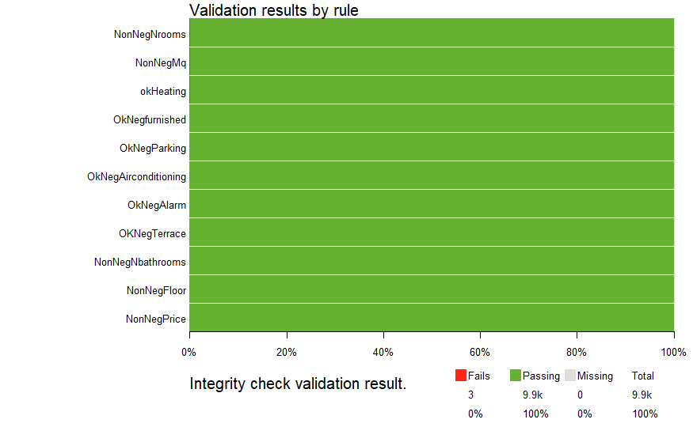

```r
plot(qualcheck_integrity, xlab = "Integrity check validation result.")
```

3 columns have failed in integrity check (1)Heating (2)mq (3) n_rooms.

**Missing value check**

```r
qualcheck_missing <-confront(newdf,missing.rules)
summary(qualcheck_missing)
```

| name | items | passes | fails | nNA | error | warning | expression |
| --- | --- | --- | --- | --- | --- | --- | --- |
| missing.NA_price | 903 | 903 | 0 | 0 | FALSE | FALSE | !is.na(price) |
| missing.NAN_price | 903 | 903 | 0 | 0 | FALSE | FALSE | !is.nan(price) |
| missing.NA_mq | 903 | 903 | 0 | 0 | FALSE | FALSE | !is.na(mq) |
| missing.NAN_mq | 903 | 903 | 0 | 0 | FALSE | FALSE | !is.nan(mq) |
| missing.NA_floor | 903 | 903 | 0 | 0 | FALSE | FALSE | !is.na(floor) |
| missing.NAN_floor | 903 | 903 | 0 | 0 | FALSE | FALSE | !is.nan(floor) |
| missing.NA_n_rooms | 903 | 903 | 0 | 0 | FALSE | FALSE | !is.na(n_rooms) |
| missing.NAN_n_rooms | 903 | 903 | 0 | 0 | FALSE | FALSE | !is.nan(n_rooms) |
| missing.NA_n_bathrooms | 903 | 903 | 0 | 0 | FALSE | FALSE | !is.na(n_bathrooms) |
| missing.NAN_n_bathrooms | 903 | 903 | 0 | 0 | FALSE | FALSE | !is.nan(n_bathrooms) |

[output cut: 12 more lines]

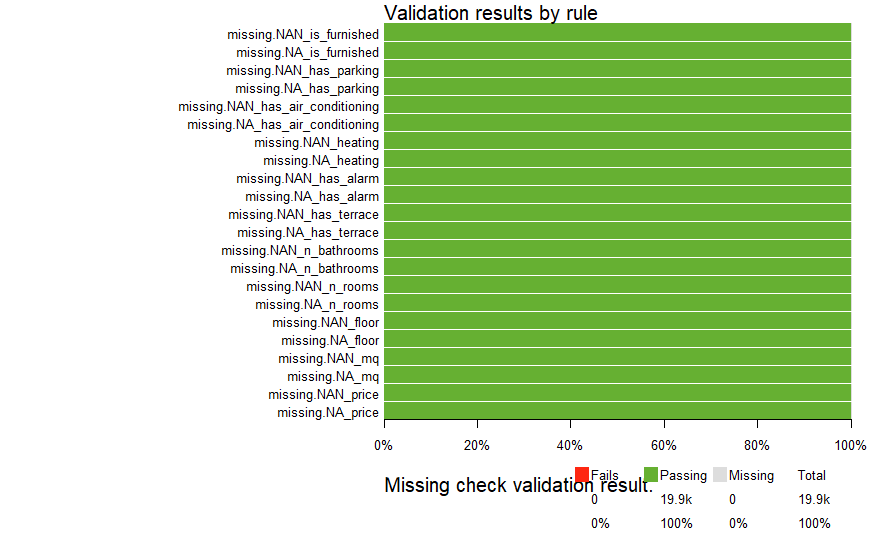

```r
plot(qualcheck_missing, xlab = "Missing check validation result.")
```

There are no NA and NAN values in dataframe.

**Uniqueness check**

```r
cat("number of unique rows before unique_check test = ",  nrow(newdf), "\n")
```

```
number of unique rows before unique_check test =  903
```

```r
newdf <- unique_check(newdf)
cat("number of unique rows after unique_check test = ",  nrow(newdf))
```

```
number of unique rows after unique_check test =  903
```

There are no duplicate rows available in our dataframe newdf.

**Variable type check**

```r
qualcheck_variabletype <-confront(newdf,variabletype.rule)

summary(qualcheck_variabletype)
```

| name | items | passes | fails | nNA | error | warning | expression |
| --- | --- | --- | --- | --- | --- | --- | --- |
| variable_price | 1 | 1 | 0 | 0 | FALSE | FALSE | is.numeric(price) |
| variable_mq | 1 | 1 | 0 | 0 | FALSE | FALSE | is.numeric(mq) |
| variable_floor | 1 | 0 | 1 | 0 | FALSE | FALSE | is.factor(floor) |
| variable_n_rooms | 1 | 0 | 1 | 0 | FALSE | FALSE | is.factor(n_rooms) |
| variable_n_bathrooms | 1 | 0 | 1 | 0 | FALSE | FALSE | is.factor(n_bathrooms) |
| variable_has_terrace | 1 | 0 | 1 | 0 | FALSE | FALSE | is.factor(has_terrace) |
| variable_has_alarm | 1 | 0 | 1 | 0 | FALSE | FALSE | is.factor(has_alarm) |
| variable_heating | 1 | 0 | 1 | 0 | FALSE | FALSE | is.factor(heating) |
| variable_has_air_conditioning | 1 | 0 | 1 | 0 | FALSE | FALSE | is.factor(has_air_conditioning) |
| variable_has_parking | 1 | 0 | 1 | 0 | FALSE | FALSE | is.factor(has_parking) |

[output cut: 1 more lines]

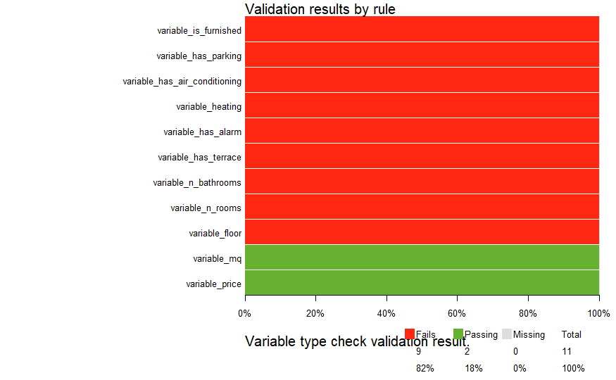

```r
plot(qualcheck_variabletype, xlab = "Variable type check validation result.")
```

As per above result 9 columns (is_furnished, has_terrace,has_alarm, heating, has_air_conditioning, has_parking, n_bathrooms, n_rooms, floor) have failed variable class test.

**Accuracy Check** I have put lower cap of 5000 and upper cap of 1000000 on price to maintain accuracy of housing price.

```r
Outliers_price <- remove_outliers_cap(newdf, 5000, 1000000)
nrow(Outliers_price)
```

```
[1] 0
```

There is no property exist which has price below 5000 or above 1000000. All records has passed accuracy check. So, I don’t need to remove any outliers from property column.

**Checking frequency of all columns which has Categorical or ordinal data**

```r
table(newdf$floor)
```

```
  1   2   3   4   5   6   7   8   9
467 268  96  41  19   8   1   2   1
```

```r
table(newdf$n_rooms)
```

```
 -1   2   3   4   5
  1 171 309 272 150
```

```r
table(newdf$n_bathrooms)
```

```
  1   2   3
559 296  48
```

```r
table(newdf$has_terrace)
```

```
  0   1
782 121
```

```r
table(newdf$has_alarm)
```

```
  0   1
891  12
```

```r
table(newdf$heating)
```

```
autonamous autonomous      other
         1        793        109
```

```r
table(newdf$has_air_conditioning)
```

```
  0   1
618 285
```

```r
table(newdf$has_parking)
```

```
  0   1
890  13
```

```r
table(newdf$is_furnished)
```

```
  0   1
850  53
```

/

**Quality check for area (mq)**

```r
faulty_mq <- newdf[newdf$mq < 25, ]  # area (mq) less than 25 will be filtered
faulty_mq
```

|  | id | price | mq | floor | n_rooms | n_bathrooms | has_terrace | has_alarm | heating | has_air_conditioning | has_parking | is_furnished |
| --- | --- | --- | --- | --- | --- | --- | --- | --- | --- | --- | --- | --- |
| 88190 | 88190 | 100000 | 1 | 2 | 4 | 1 | 0 | 0 | other | 1 | 0 | 0 |
| 197321 | 197321 | 78000 | 0 | 2 | 3 | 1 | 0 | 0 | autonomous | 0 | 0 | 0 |

## 1.3 Data cleaning

**Result Summary of Quality check analysis**

Below is the list of quality issue found in dataframe.

**Solving Data Quality Issue**

1. I will Convert (update) ‘autonamous’ value in to ‘autonomous’, in ‘heating’ column.
2. I will remove 2 records which has less than 25 value in mq (area) column.
3. I will remove 1 record which has negative value in n_rooms column.
4. I will converts column type as “factor” in 9 columns (is_furnished, has_terrace,has_alarm, heating, has_air_conditioning, has_parking, n_bathrooms, n_rooms, floor).

Convert ‘autonamous’ value in to ‘autonomous’, in ‘heating’ variable.

```r
newdf$heating[which(newdf$heating == "autonamous")] = "autonomous"
table(newdf$heating)
```

```
autonomous      other
       794        109
```

Removing rows with “mq” records below 25

```r
newdf <- newdf[newdf$mq >= 25 , ]  # remove rows which has less than 25 mq
nrow(newdf)
```

```
[1] 901
```

```r
Sorted_mq <- newdf
Sorted_mq <-Sorted_mq[order(Sorted_mq$mq),] # sorted data according to mq
head(Sorted_mq$mq)  # sorted mq column after removing values less than 25
```

```
[1] 26 30 30 31 33 35
```

removing rows with negative n_rooms value.

```r
newdf <- newdf[newdf$n_rooms > 0, ]  # remove rows which has less than 1 rooms

table(newdf$n_rooms)
```

```
  2   3   4   5
171 308 271 150
```

```r
nrow(newdf)
```

```
[1] 900
```

```r
newdf$has_terrace = as.factor(newdf$has_terrace)

newdf$has_alarm = as.factor(newdf$has_alarm)

newdf$heating = as.factor(newdf$heating)

newdf$has_air_conditioning = as.factor(newdf$has_air_conditioning)

newdf$has_parking = as.factor(newdf$has_parking)

newdf$is_furnished = as.factor(newdf$is_furnished)

newdf$n_bathrooms = as.factor(newdf$n_bathrooms)

newdf$n_rooms = as.factor(newdf$n_rooms)

newdf$floor = as.factor(newdf$floor)
```

After data cleaning, let’s pass our data frame ‘newdf’ from ‘validator’ function, once again, and apply ‘integrity.rules’ to ‘newdf’ data frame.

```r
qualcheck_integrity2 <-confront(newdf,integrity.rules)
summary(qualcheck_integrity2)
```

| name | items | passes | fails | nNA | error | warning | expression |
| --- | --- | --- | --- | --- | --- | --- | --- |
| okHeating | 900 | 900 | 0 | 0 | FALSE | FALSE | is.element(heating, c("autonomous", "other")) |
| NonNegPrice | 900 | 900 | 0 | 0 | FALSE | FALSE | price > 0 |
| NonNegMq | 900 | 900 | 0 | 0 | FALSE | FALSE | mq > 0 |
| NonNegFloor | 900 | 0 | 0 | 900 | FALSE | TRUE | floor > 0 |
| NonNegNrooms | 900 | 0 | 0 | 900 | FALSE | TRUE | n_rooms > 0 |
| NonNegNbathrooms | 900 | 0 | 0 | 900 | FALSE | TRUE | n_bathrooms >= 0 |
| OKNegTerrace | 900 | 900 | 0 | 0 | FALSE | FALSE | is.element(has_terrace, c("0", "1")) |
| OkNegAlarm | 900 | 900 | 0 | 0 | FALSE | FALSE | is.element(has_alarm, c("0", "1")) |
| OkNegAirconditioning | 900 | 900 | 0 | 0 | FALSE | FALSE | is.element(has_air_conditioning, c("0", "1")) |
| OkNegParking | 900 | 900 | 0 | 0 | FALSE | FALSE | is.element(has_parking, c("0", "1")) |

[output cut: 1 more lines]

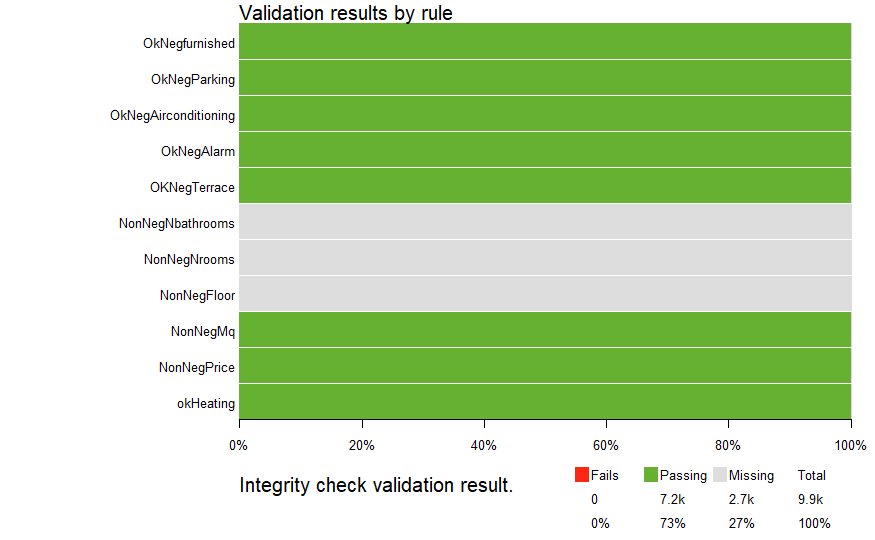

```r
plot(qualcheck_integrity2, xlab = "Integrity check validation result.")
```

**There are 900 rows remaining after completion of data cleaning.**

# 2. Exploratory Data Analysis (EDA)

## 2.1 EDA plan

In this section, I will check co-relation of price with other variable, and then I will use various plots like histogram, scatter plot, barplot and boxplot to understand data distribution and relation between variables.

A histogram is a graph that shows the frequency of data within specific ranges or bins. It is used to visualize the distribution of continuous variables.

A scatter plot is a graph that shows the relationship between two continuous variables. It is used to visualize the relationship between two variables and see if there is a pattern or trend.

A bar plot is a graph that shows the frequency of data in categories or groups. It is used to compare the frequency of different categories or to compare the proportions of different categories.

The box in the box plot represents the interquartile range, which is the range of values between the first quartile (Q1) and the third quartile (Q3). The median (Q2) is represented by a line within the box. The whiskers of the plot extend from the box to the minimum and maximum values, and any outliers are represented by individual points.

**Testing Correlation of price with mq columns.**

Test correlation between Price and mq(area)

$H_0: \rho=0$ vs $H_1:\rho \ne 0$

```r
cor.test(newdf$price, newdf$mq)
```

```
    Pearson's product-moment correlation

data:  newdf$price and newdf$mq
t = 13.215, df = 898, p-value < 2.2e-16
alternative hypothesis: true correlation is not equal to 0
95 percent confidence interval:
 0.3473136 0.4568065
sample estimates:
      cor
0.4035036
```

Result shows that p-value < 2.2e-16. We reject the Null Hypothesis. These two variables are correlated (considering alpha = 0.05). Cor value is 0.4035036. It means they are weakly positively co related.

We can use scatter plot to visualized this relationship.

**Scatter Plot**

**Scatter plot of Property Price and Area(mq))**

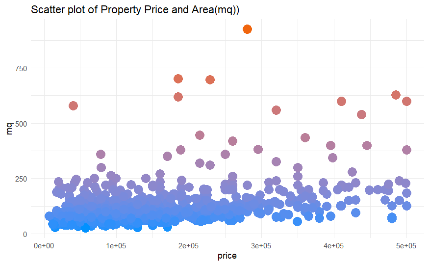

```r
ggplot(newdf, aes(price, mq, color = mq)) +
  geom_point(shape = 16, size = 5, show.legend = FALSE) +
  theme_minimal() +
  scale_color_gradient(low = "#0091ff", high = "#f0650e") + ggtitle("Scatter plot of Property Price and Area(mq))")
```

**Scatter plot of log(Price) and log(Area(mq))**

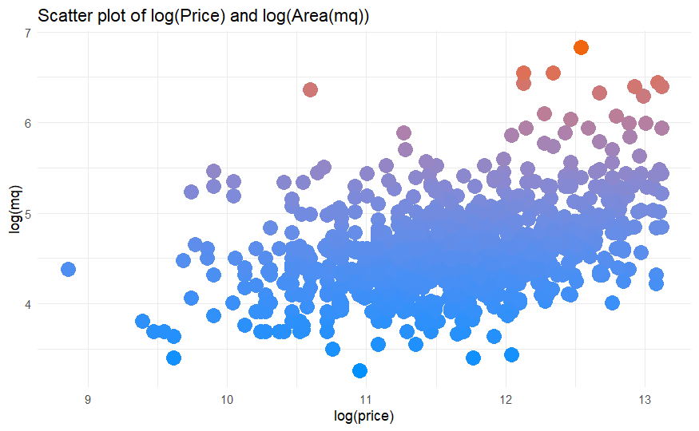

```r
ggplot(newdf, aes(log(price), log(mq), color = mq)) +
  geom_point(shape = 16, size = 5, show.legend = FALSE) +
  theme_minimal() +
  scale_color_gradient(low = "#0091ff", high = "#f0650e") + ggtitle("Scatter plot of log(Price) and log(Area(mq))")
```

**Histogram**

**Histogram of Price**

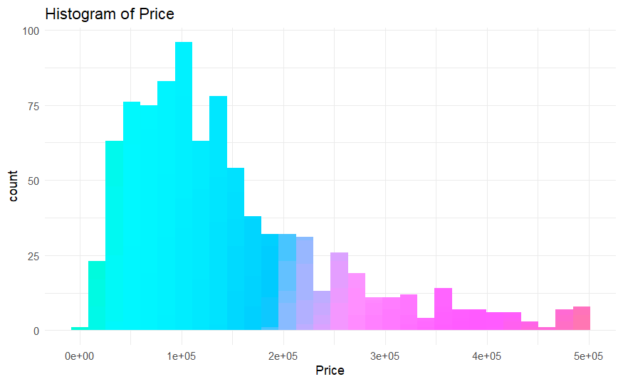

```r
p <- ggplot(newdf, aes(x = price, fill = cut(price, 100))) +
  geom_histogram(show.legend = FALSE) +
  theme_minimal() +
  labs(x = "Price", y = "count") +
  ggtitle("Histogram of Price")

p + scale_fill_discrete(h = c(180, 360), c = 150, l = 80)
```

**Histogram of Price after convert price in log**

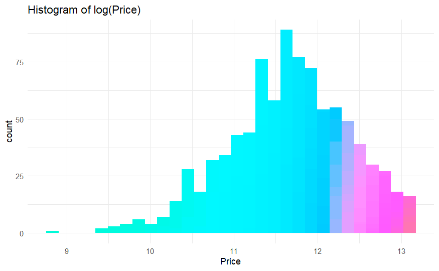

```r
p <- ggplot(newdf, aes(x = log(price), fill = cut(price, 100))) +
  geom_histogram(show.legend = FALSE) +
  theme_minimal() +
  labs(x = "Price", y = "count") +
  ggtitle("Histogram of log(Price)")

p + scale_fill_discrete(h = c(180, 360), c = 150, l = 80)
```

**Histogram of area (mq)**

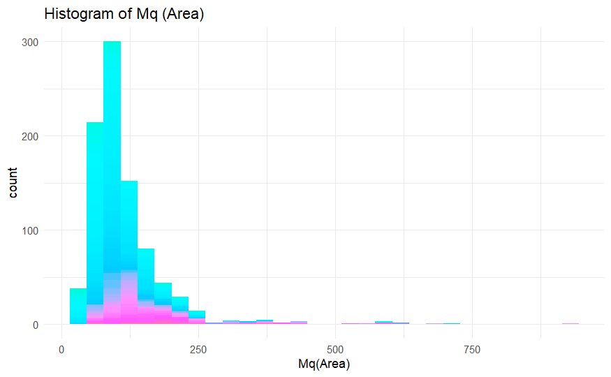

```r
p <- ggplot(newdf, aes(x = mq, fill = cut(price, 100))) +
  geom_histogram(show.legend = FALSE) +
  theme_minimal() +
  labs(x = "Mq(Area)", y = "count") +
  ggtitle("Histogram of Mq (Area)")

p + scale_fill_discrete(h = c(180, 360), c = 150, l = 80)
```

[figure not shown]

```r
p <- ggplot(newdf, aes(x = mq, fill = cut(price, 100))) +
  geom_histogram(show.legend = FALSE) +
  theme_minimal() +
  labs(x = "Price", y = "count") +
  ggtitle("Histogram of log(mq(area))")

p + scale_fill_discrete(h = c(180, 360), c = 150, l = 80)
```

**Bar Plot**

**Bar plot of log(Price) and n_rooms**

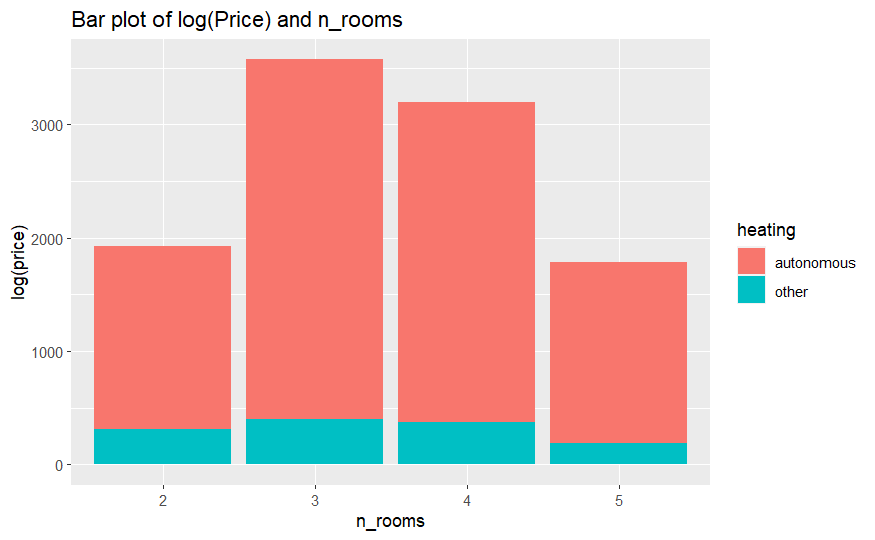

```r
ggplot(newdf, aes(x = n_rooms, y = log(price), fill = heating)) +
  geom_col() + ggtitle("Bar plot of log(Price) and n_rooms")
```

**Bar plot of log(Price) and has_parking**

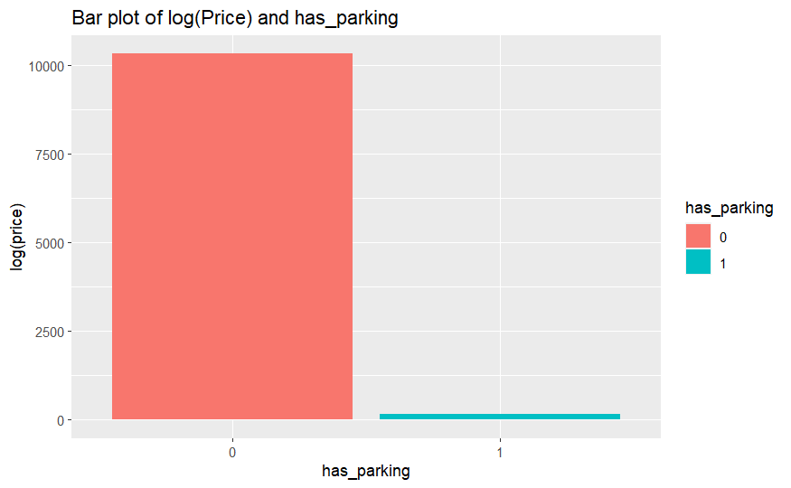

```r
ggplot(newdf, aes(x = has_parking, y = log(price), fill = has_parking)) +
  geom_col() + ggtitle("Bar plot of log(Price) and has_parking")
```

**Bar plot of log(Price) and n_bathrooms**

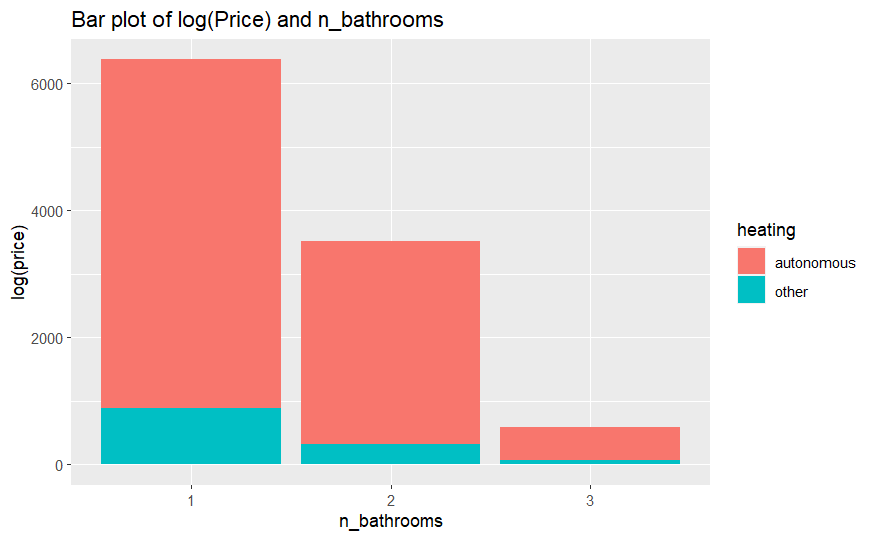

```r
ggplot(newdf, aes(x = n_bathrooms, y = log(price), fill = heating)) +
  geom_col() + ggtitle("Bar plot of log(Price) and n_bathrooms")
```

**Bar plot of log(Price) and has_alarm**

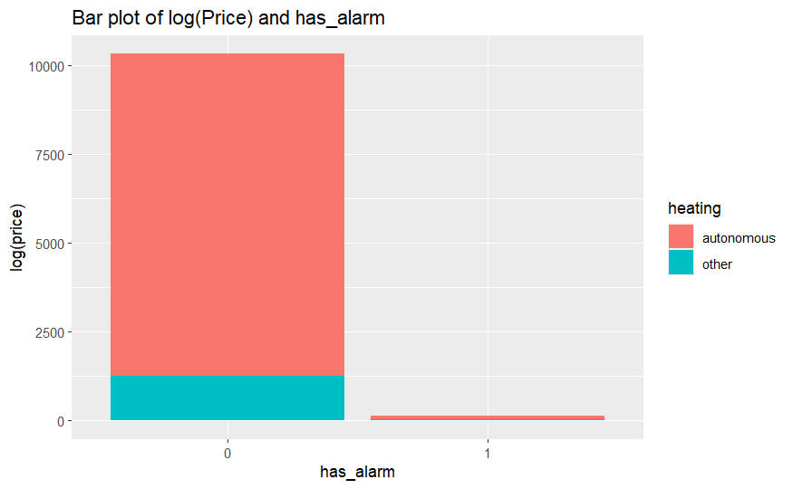

```r
ggplot(newdf, aes(x = has_alarm, y = log(price), fill = heating)) +
  geom_col() + ggtitle("Bar plot of log(Price) and has_alarm")
```

**Bar plot of log(Price) and heating**

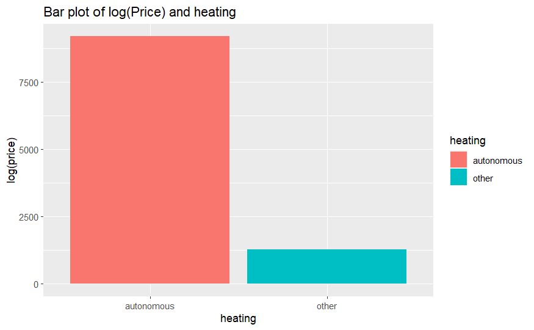

```r
ggplot(newdf, aes(x = heating, y = log(price), fill = heating )) +
  geom_col() + ggtitle("Bar plot of log(Price) and heating")
```

**Bar plot of log(Price) and has_air_conditioning**

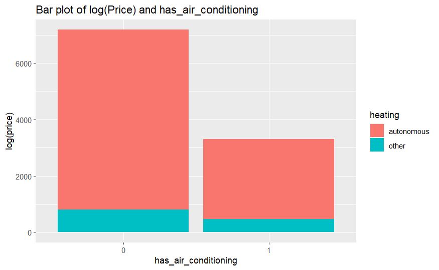

```r
ggplot(newdf, aes(x = has_air_conditioning, y = log(price), fill = heating)) +
  geom_col() + ggtitle("Bar plot of log(Price) and has_air_conditioning")
```

**Bar plot of log(Price) and has_parking**